# Assignment 6 Regression

Sanket

2024-11-17

1. Find an independent variable to predict your time-serie In this analysis, we’re predicting the MortalityRate (the rate at which deaths occur). To do that, we’ve chosen FertilityRate (birth rate) as our independent variable. This choice makes sense because fertility trends often impact mortality patterns, potentially through socio-economic factors or healthcare resource allocation.

```r
options(repos = c(CRAN = "https://cloud.r-project.org"))

#install.packages
library(readxl)
library(knitr)
library(TTR)
library(dplyr)
library(ggplot2)
library(forecast)
library(tidyverse)
# Load the Excel file
data  <- read.csv("C:/Users/Sanket Khamkar/Downloads/Data Dictionary_Sanket.csv")
names(data)
```

```
## [1] "Year_Quarter"     "Birth.rate.group" "Indicator"        "Group"
## [5] "FertilityRate"    "Unit"             "MortalityRate"
```

```r
knitr::kable(data)
```

| Year_Quarter | Birth.rate.group | Indicator | Group | FertilityRate | Unit | MortalityRate |
| --- | --- | --- | --- | --- | --- | --- |
| 2024 Q1 | Age-specific Birth Rates | 10-14 years | All races and origins | 0.2 | per 1,000 population | 0.008 |
| 2024 Q1 | Age-specific Birth Rates | 10-14 years | Hispanic | 0.3 | per 1,000 population | 0.012 |
| 2024 Q1 | Age-specific Birth Rates | 10-14 years | Non-Hispanic Black | 0.3 | per 1,000 population | 0.012 |
| 2024 Q1 | Age-specific Birth Rates | 10-14 years | Non-Hispanic White | 0.1 | per 1,000 population | 0.004 |
| 2024 Q1 | Age-specific Birth Rates | 15-19 years | All races and origins | 13.2 | per 1,000 population | 0.528 |
| 2024 Q1 | Age-specific Birth Rates | 15-19 years | Hispanic | 21.3 | per 1,000 population | 0.852 |
| 2024 Q1 | Age-specific Birth Rates | 15-19 years | Non-Hispanic Black | 19.1 | per 1,000 population | 0.764 |
| 2024 Q1 | Age-specific Birth Rates | 15-19 years | Non-Hispanic White | 8.5 | per 1,000 population | 0.340 |
| 2024 Q1 | Age-specific Birth Rates | 20-24 years | All races and origins | 55.1 | per 1,000 population | 2.204 |
| 2024 Q1 | Age-specific Birth Rates | 20-24 years | Hispanic | 78.3 | per 1,000 population | 3.132 |
| 2024 Q1 | Age-specific Birth Rates | 20-24 years | Non-Hispanic Black | 65.3 | per 1,000 population | 2.612 |
| 2024 Q1 | Age-specific Birth Rates | 20-24 years | Non-Hispanic White | 46.0 | per 1,000 population | 1.840 |
| 2024 Q1 | Age-specific Birth Rates | 25-29 years | All races and origins | 91.1 | per 1,000 population | 3.644 |
| 2024 Q1 | Age-specific Birth Rates | 25-29 years | Hispanic | 112.5 | per 1,000 population | 4.500 |
| 2024 Q1 | Age-specific Birth Rates | 25-29 years | Non-Hispanic Black | 84.2 | per 1,000 population | 3.368 |
| 2024 Q1 | Age-specific Birth Rates | 25-29 years | Non-Hispanic White | 89.2 | per 1,000 population | 3.568 |
| 2024 Q1 | Age-specific Birth Rates | 30-34 years | All races and origins | 95.6 | per 1,000 population | 3.824 |
| 2024 Q1 | Age-specific Birth Rates | 30-34 years | Hispanic | 102.4 | per 1,000 population | 4.096 |
| 2024 Q1 | Age-specific Birth Rates | 30-34 years | Non-Hispanic Black | 76.4 | per 1,000 population | 3.056 |
| 2024 Q1 | Age-specific Birth Rates | 30-34 years | Non-Hispanic White | 98.3 | per 1,000 population | 3.932 |
| 2024 Q1 | Age-specific Birth Rates | 35-39 years | All races and origins | 55.0 | per 1,000 population | 2.200 |
| 2024 Q1 | Age-specific Birth Rates | 35-39 years | Hispanic | 60.2 | per 1,000 population | 2.408 |
| 2024 Q1 | Age-specific Birth Rates | 35-39 years | Non-Hispanic Black | 49.7 | per 1,000 population | 1.988 |
| 2024 Q1 | Age-specific Birth Rates | 35-39 years | Non-Hispanic White | 52.6 | per 1,000 population | 2.104 |
| 2024 Q1 | Age-specific Birth Rates | 40-44 years | All races and origins | 12.8 | per 1,000 population | 0.512 |
| 2024 Q1 | Age-specific Birth Rates | 40-44 years | Hispanic | 15.8 | per 1,000 population | 0.632 |
| 2024 Q1 | Age-specific Birth Rates | 40-44 years | Non-Hispanic Black | 14.1 | per 1,000 population | 0.564 |
| 2024 Q1 | Age-specific Birth Rates | 40-44 years | Non-Hispanic White | 10.7 | per 1,000 population | 0.428 |
| 2024 Q1 | Age-specific Birth Rates | 45+ years | All races and origins | 1.1 | per 1,000 population | 0.044 |
| 2024 Q1 | Age-specific Birth Rates | 45+ years | Hispanic | 1.1 | per 1,000 population | 0.044 |

[output cut: 438 more lines]

```r
head(data)
```

```
##   Year_Quarter         Birth.rate.group   Indicator                 Group
## 1      2024 Q1 Age-specific Birth Rates 10-14 years All races and origins
## 2      2024 Q1 Age-specific Birth Rates 10-14 years              Hispanic
## 3      2024 Q1 Age-specific Birth Rates 10-14 years    Non-Hispanic Black
## 4      2024 Q1 Age-specific Birth Rates 10-14 years    Non-Hispanic White
## 5      2024 Q1 Age-specific Birth Rates 15-19 years All races and origins
## 6      2024 Q1 Age-specific Birth Rates 15-19 years              Hispanic
##   FertilityRate                 Unit MortalityRate
## 1           0.2 per 1,000 population         0.008
## 2           0.3 per 1,000 population         0.012
## 3           0.3 per 1,000 population         0.012
## 4           0.1 per 1,000 population         0.004
## 5          13.2 per 1,000 population         0.528
## 6          21.3 per 1,000 population         0.852
```

```r
# Function to convert 'Year_Quarter' to start date for each quarter
convert_quarter_to_date <- function(quarter) {
  if (is.na(quarter)) {
    return(NA)  # Return NA if quarter is missing
  }
  year <- as.numeric(substr(quarter, 1, 4))
  q <- substr(quarter, 6, 7)

  if (q == "Q1") {
    return(as.Date(paste0(year, "-01-01")))
  } else if (q == "Q2") {
    return(as.Date(paste0(year, "-04-01")))
  } else if (q == "Q3") {
    return(as.Date(paste0(year, "-07-01")))
  } else if (q == "Q4") {
    return(as.Date(paste0(year, "-10-01")))
  } else {
    return(NA)  # Return NA if the quarter is not in a recognized format
  }
}

# Apply the conversion to the 'Year Quarter' column
data$Date <- sapply(data$`Year_Quarter`, convert_quarter_to_date)

# Convert the 'Rate' column to numeric and clean up the data
data$FertilityRate <- as.numeric(data$FertilityRate)
data <- data[!is.na(data$Date) & !is.na(data$FertilityRate), ]
data$MortalityRate <- as.numeric(data$MortalityRate)
data <- data[!is.na(data$Date) & !is.na(data$MortalityRate), ]
# Ensure Date column is a factor (or convert as needed)
data$Date <- as.factor(data$Date)
```

2. Perform regression

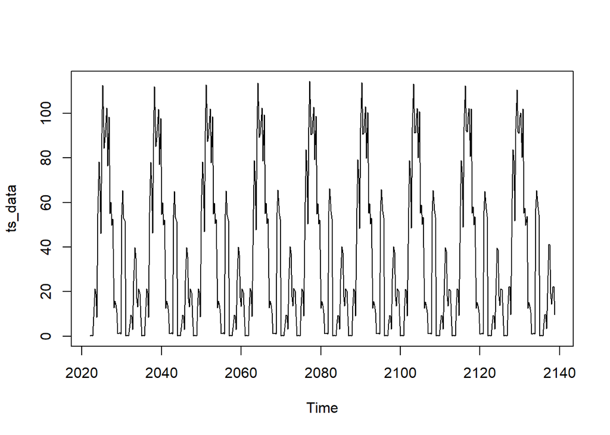

```r
# Create a time series object with quarterly frequency (4 quarters per year)
ts_data <- ts(data$FertilityRate, start=c(2022, 1), frequency=4)
plot(ts_data)
```

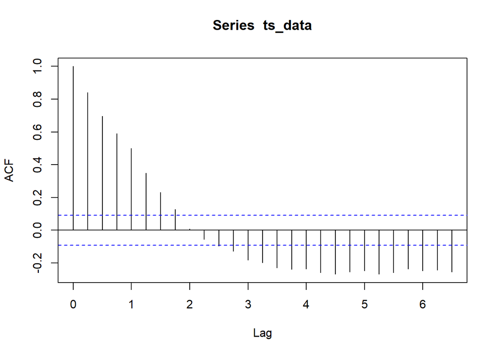

```r
acf(ts_data)
```

```r
str(data$FertilityRate)
```

```
##  num [1:468] 0.2 0.3 0.3 0.1 13.2 21.3 19.1 8.5 55.1 78.3 ...
```

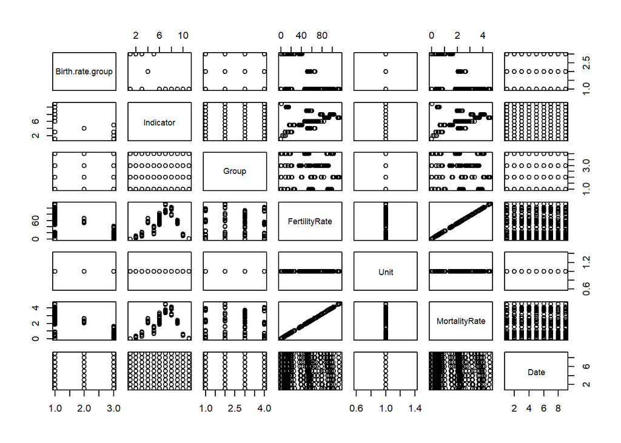

```r
# Plot the time series

# Pairwise plots to see relationships
plot(data[,-1])  # Remove non-numeric columns, if necessary
```

```r
# Select only numeric columns for the pairs plot
numeric_data <- data[sapply(data, is.numeric)]


str(numeric_data)
```

```
## 'data.frame':    468 obs. of  2 variables:
##  $ FertilityRate: num  0.2 0.3 0.3 0.1 13.2 21.3 19.1 8.5 55.1 78.3 ...
##  $ MortalityRate: num  0.008 0.012 0.012 0.004 0.528 ...
```

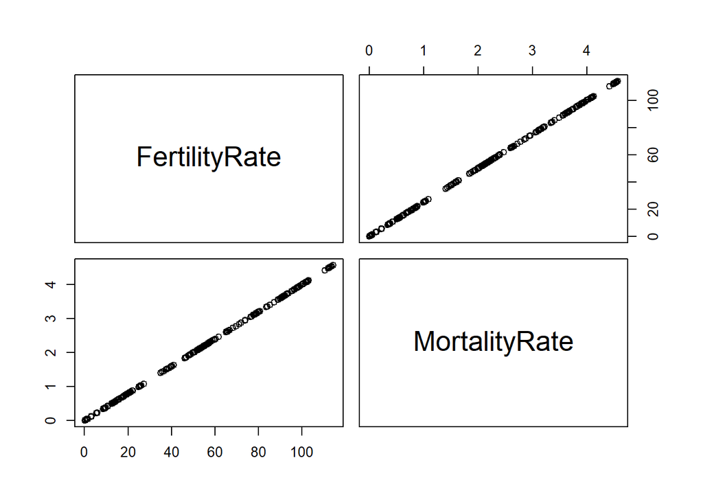

```r
# Plot pairs only if there are at least two numeric columns
if (ncol(numeric_data) > 1) {
    pairs(numeric_data)
} else {
    print("Not enough numeric columns for pairwise plot")
}
```

```r
# Summary and correlation
summary(data)
```

```
##  Year_Quarter       Birth.rate.group    Indicator            Group
##  Length:468         Length:468         Length:468         Length:468
##  Class :character   Class :character   Class :character   Class :character
##  Mode  :character   Mode  :character   Mode  :character   Mode  :character
##
##
##
##
##  FertilityRate        Unit           MortalityRate        Date
##  Min.   :  0.10   Length:468         Min.   :0.004   18993  : 52
##  1st Qu.:  4.95   Class :character   1st Qu.:0.198   19083  : 52
##  Median : 20.20   Mode  :character   Median :0.808   19174  : 52
##  Mean   : 34.65                      Mean   :1.386   19266  : 52
##  3rd Qu.: 56.52                      3rd Qu.:2.261   19358  : 52
##  Max.   :114.30                      Max.   :4.572   19448  : 52
##                                                      (Other):156
```

```r
cor(numeric_data)
```

```
##               FertilityRate MortalityRate
## FertilityRate             1             1
## MortalityRate             1             1
```

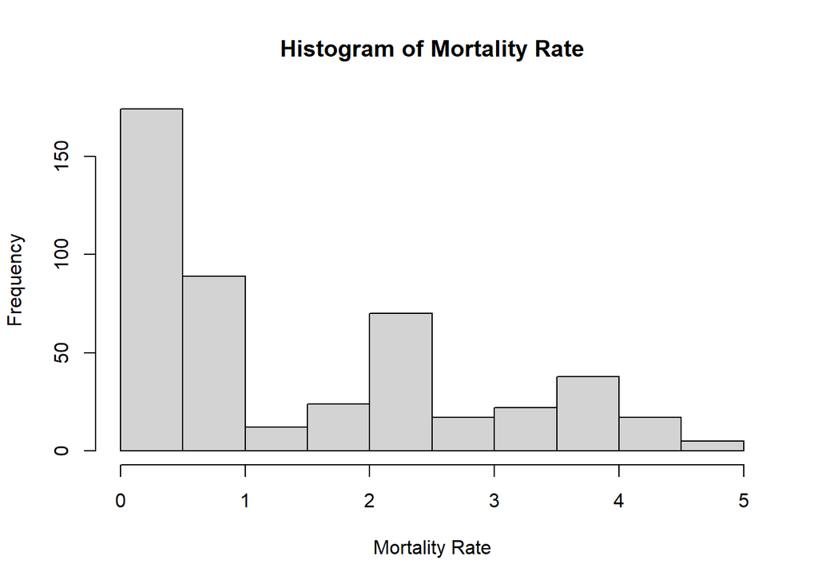

```r
# Histograms and Scatter Plots
hist(data$MortalityRate, main="Histogram of Mortality Rate", xlab="Mortality Rate")
```

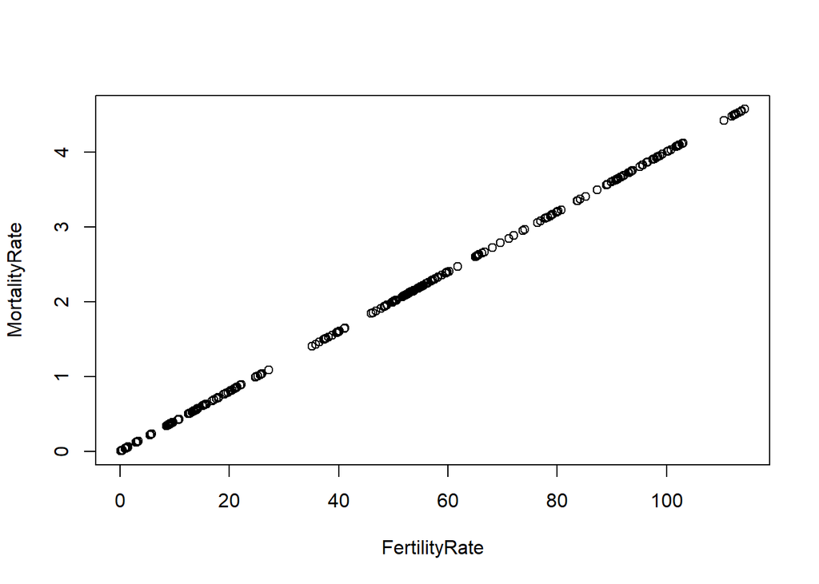

```r
plot(MortalityRate ~ FertilityRate, data=data)
```

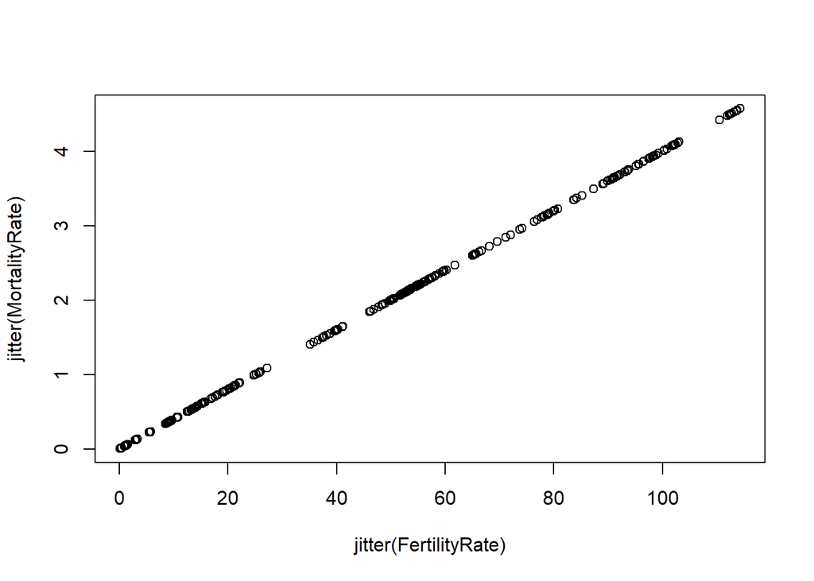

```r
plot(jitter(MortalityRate) ~ jitter(FertilityRate), data=data)
```

```r
# Fit linear regression model
fit <- lm(MortalityRate ~ FertilityRate, data=data)
print(fit)
```

```
##
## Call:
## lm(formula = MortalityRate ~ FertilityRate, data = data)
##
## Coefficients:
##   (Intercept)  FertilityRate
##     2.628e-15      4.000e-02
```

3. Perform Model Acceptance Steps and show the interpretation of the model output

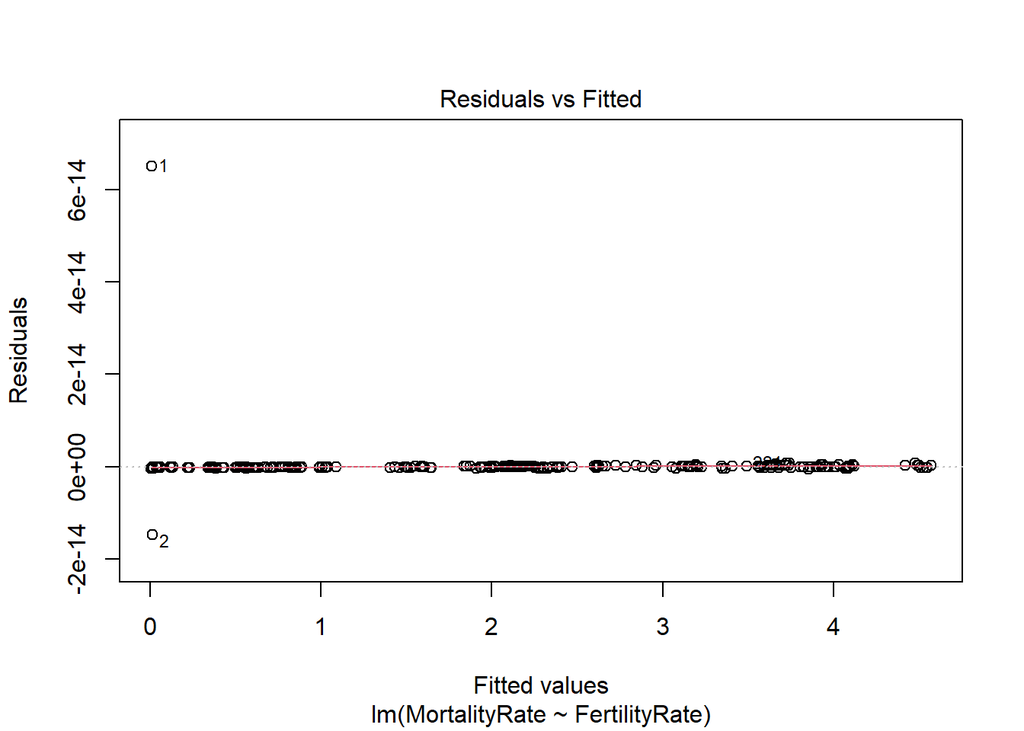

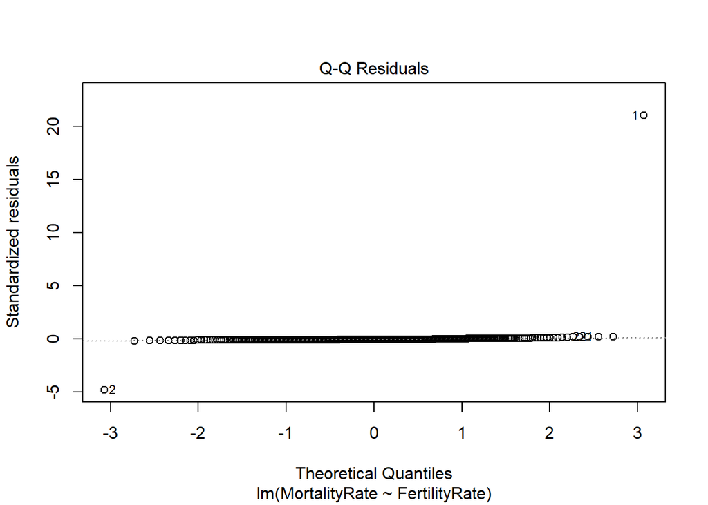

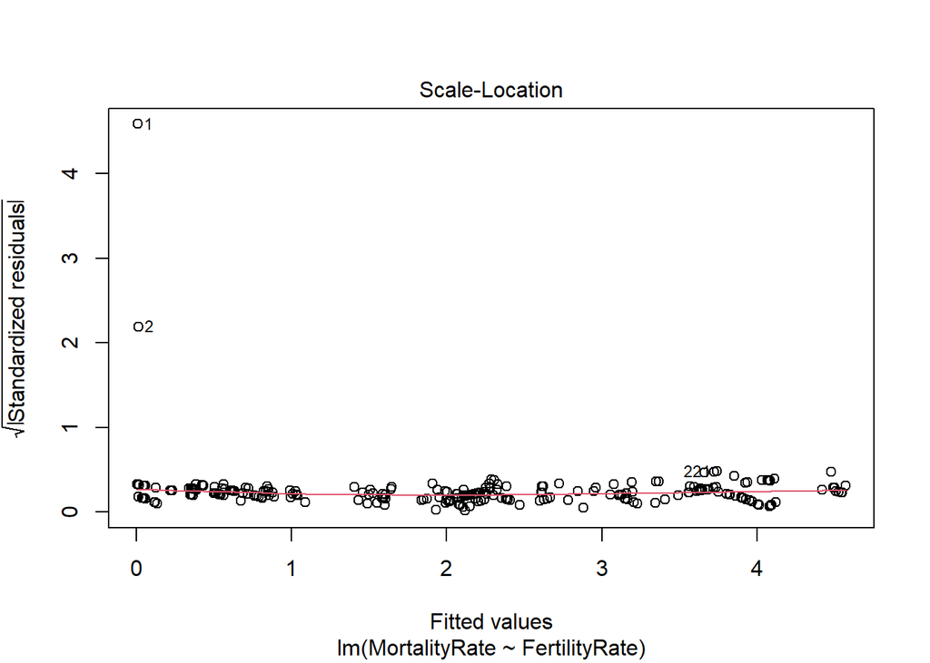

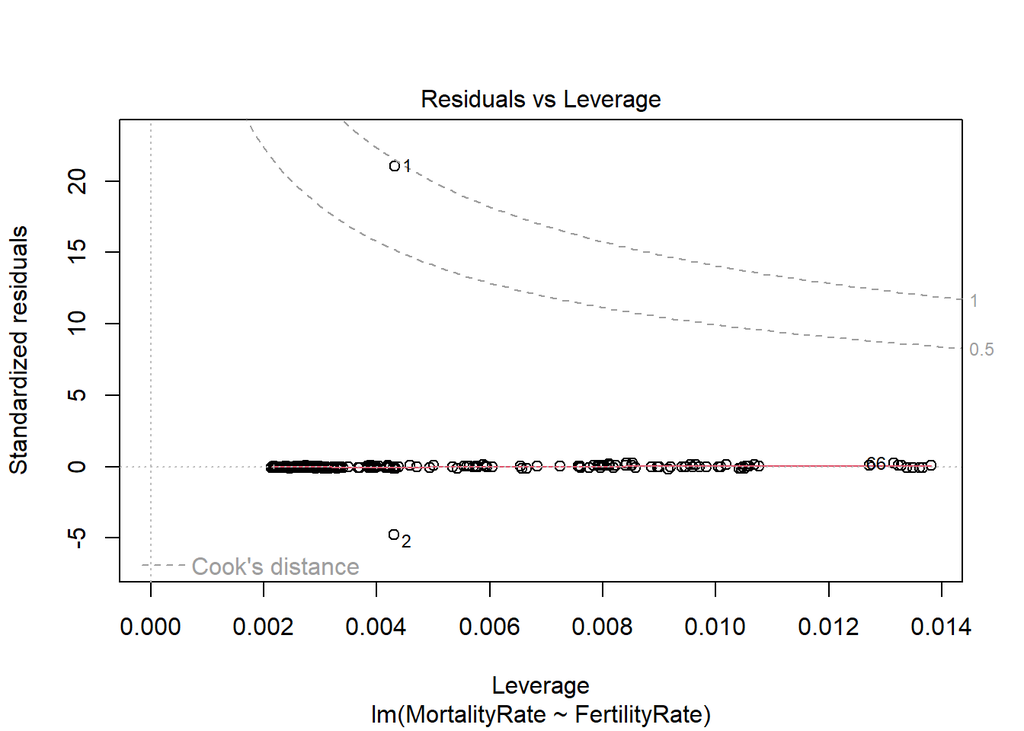

```r
# Diagnostic plots for the model
plot(fit)
```

```r
summary(fit)
```

```
##
## Call:
## lm(formula = MortalityRate ~ FertilityRate, data = data)
##
## Residuals:
##        Min         1Q     Median         3Q        Max
## -1.481e-14 -2.350e-16 -1.260e-16 -4.200e-17  6.502e-14
##
## Coefficients:
##                Estimate Std. Error   t value Pr(>|t|)
## (Intercept)   2.628e-15  2.041e-16 1.287e+01   <2e-16 ***
## FertilityRate 4.000e-02  4.201e-18 9.522e+15   <2e-16 ***
## ---
## Signif. codes:  0 '***' 0.001 '**' 0.01 '*' 0.05 '.' 0.1 ' ' 1
##
## Residual standard error: 3.097e-15 on 466 degrees of freedom
## Multiple R-squared:      1,  Adjusted R-squared:      1
## F-statistic: 9.068e+31 on 1 and 466 DF,  p-value: < 2.2e-16
```

```r
anova(fit)
```

```
## Analysis of Variance Table
##
## Response: MortalityRate
##                Df Sum Sq Mean Sq    F value    Pr(>F)
## FertilityRate   1 869.65  869.65 9.0676e+31 < 2.2e-16 ***
## Residuals     466   0.00    0.00
## ---
## Signif. codes:  0 '***' 0.001 '**' 0.01 '*' 0.05 '.' 0.1 ' ' 1
```

Lastly, the ANOVA output confirms the significance of the fertility rate as a predictor. If the p-value is very low (like < 2.2e-16), it means that fertility rate has a statistically significant relationship with mortality rate. This high confidence level suggests a reliable association between the two.

4. Perform Residual Analysis and explain the insights

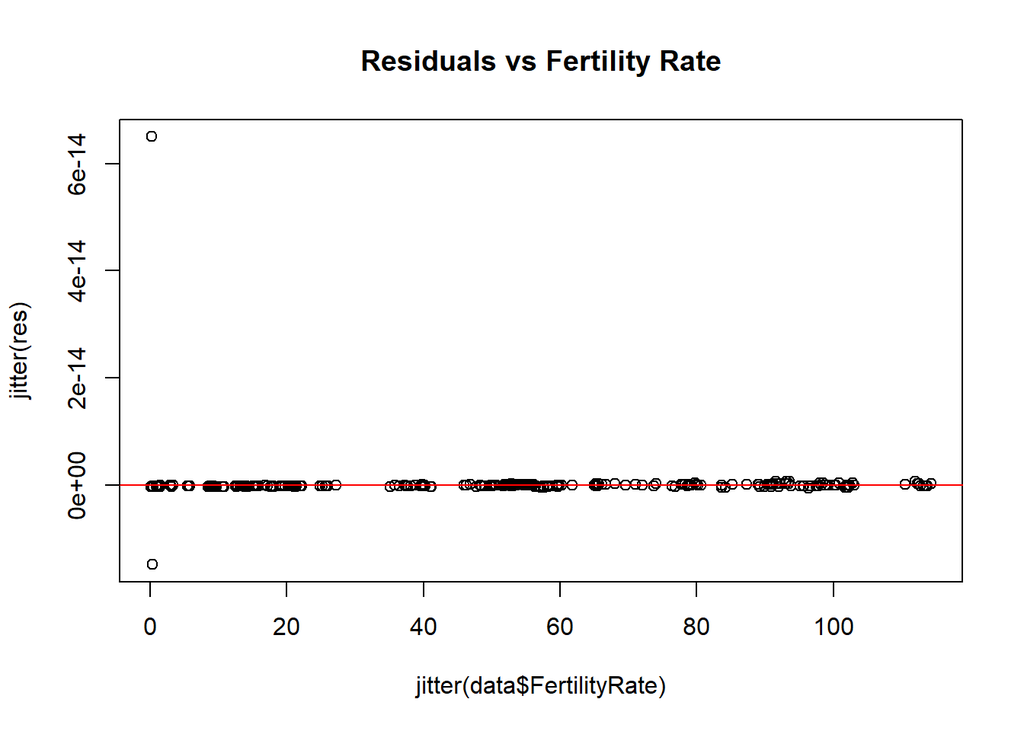

```r
# Residual analysis
res <- residuals(fit)
plot(jitter(res) ~ jitter(data$FertilityRate), main="Residuals vs Fertility Rate")
abline(h=0, col="red")
```

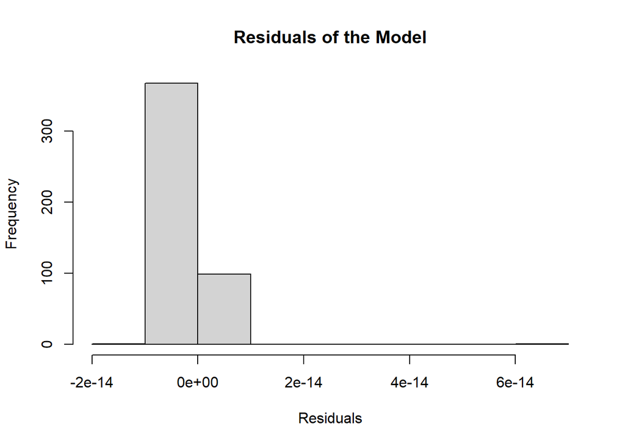

```r
hist(res, main = "Residuals of the Model", xlab = "Residuals")
```

```r
# Predicted value for the first data point
fitted(fit)[1]
```

```
##     1
## 0.008
```

To explain insights at the residuals, we will see differences between actual mortality rates and what our model predicted.

Residuals vs. Fitted Values Plot: Here, we’re looking for a random scatter of points around zero. If we see that randomness, it means our model is appropriate. But if we spot patterns, it might mean our model is missing something important.

Histogram of Residuals: This histogram shows the spread of prediction errors. Ideally, it looks like a bell curve centered at zero, which would indicate that most of our predictions are close to the actual values. If it’s skewed or off-center, it could mean our model is biased or not capturing some factors correctly.

Q-Q Plot: This plot checks if the residuals follow a normal distribution. If the points align closely with a straight line, it confirms that our errors are distributed as expected, reinforcing the model’s reliability. If not, it might hint at some model issues or the need for additional predictors.

Summary: If the residuals look random and normally distributed, it shows that fertility rate is a good predictor for mortality rate in our data. If we see patterns in residuals or deviations from normality, it might be worth revisiting the model—possibly by adding more factors, transforming some data, or even trying a different type of model to capture the relationship more accurately.